# Cleaning factorsSPGMI and stocksCRSP

Jon Spinney

30/04/2022

## Summary

stocksCRSP and factorsSPGMI are currently in the FactorAnalytics package and are to be migrated into either PCRA or another new package. Loading the data from the FactorAnalytics package:

```r
# load data from FA & create tmp copies
library(data.table)
library(FactorAnalytics)
data(factorsSPGMI)
data(stocksCRSP)
factorsSPGMI_tmp <- factorsSPGMI
stocksCRSP_tmp <- stocksCRSP
```

There are four potential issues that should be dealt with before the data can be used:

1. Sector names are misspelled and do not follow official convention for naming. I am aware that Doug prefers short names for written material, however it probably makes sense to use the official names at this stage and potentially modify them later for publication using a function.
2. There is a small subset of securities that were assigned to the wrong Sector and GICS Code originally (verified by independent checking using S&P and Bloomberg data).
3. Once cleaned, there are three sectors (Financials, Utilities, and Real Estate) each with 3 or fewer members - these should be either deleted or deleted and replaced with securities in the remaining 8 sectors (if we have access, it might make sense to delete the financials and real estate names and replace with three new utilities so that we have as many sectors as possible).
4. The Capitalization Group assignments are questionable and could be revisited. One option will be to use (for example) the CRSP approach to assigning securities to a cap group based on market cap coverage at the 0.7, 0.85, and 0.98 levels using a broad total market data set on a point in time basis. This would result in securities migrating from one cap group to another as they grow/shrink in size.

## Misspelled Sector Names

factorsSPGMI and stocksCRSP do not use official GICS naming conventions in sector names. In addition, several securities have obvious misspellings in Sector assignment, resulting in incorrect groupings. For example:

```r
unique(factorsSPGMI_tmp$Sector) # contains 16 sectors with duplications
```

```
##  [1] "InfoTech"               "Industrials"            "HealthCare"
##  [4] "ConsumStap"             "Energy"                 "Materials"
##  [7] "ConsumDisc"             "TelcoServices"          "Utilities"
## [10] "RealEstate"             "Health Care"            "Financials"
## [13] "Consumer Discretionay"  "Information Technology" "Consumer Staple"
## [16] "Communication Services"
```

For those 16 “Sectors” above, the following mapping would be correct:

| Sector (in factorsSPGMI) | Official GICS Sector Name |
| --- | --- |
| InfoTech | Information Technology |
| Industrials | Industrials |
| HealthCare | Health Care |
| ConsumStap | Consumer Staples |
| Energy | Energy |
| Materials | Materials |
| ConsumDisc | Consumer Discretionary |
| TelcoServices | Communication Services |
| Utilities | Utilities |
| RealEstate | Real Estate |
| Health Care | Health Care |
| Financials | Financials |
| Consumer Discretionay | Consumer Discretionary |
| Information Technology | Information Technology |
| Consumer Staple | Consumer Staples |
| Communication Services | Communication Services |

```r
# replacement data
bad_sectors <- unique(factorsSPGMI_tmp$Sector)
good_sectors <- c("Information Technology","Industrials","Health Care",
                  "Consumer Staples","Energy","Materials",
                  "Consumer Discretionary","Communication Services","Utilities",
                  "Real Estate","Health Care","Financials",
                  "Consumer Discretionary","Information Technology",
                  "Consumer Staples","Communication Services")
sector_table <- data.frame(cbind(bad_sectors,good_sectors))
colnames(sector_table) <- c("BadSectors","GoodSectors")
sector_table
```

```
##                BadSectors            GoodSectors
## 1                InfoTech Information Technology
## 2             Industrials            Industrials
## 3              HealthCare            Health Care
## 4              ConsumStap       Consumer Staples
## 5                  Energy                 Energy
## 6               Materials              Materials
## 7              ConsumDisc Consumer Discretionary
## 8           TelcoServices Communication Services
## 9               Utilities              Utilities
## 10             RealEstate            Real Estate
## 11            Health Care            Health Care
## 12             Financials             Financials
## 13  Consumer Discretionay Consumer Discretionary
## 14 Information Technology Information Technology
## 15        Consumer Staple       Consumer Staples
## 16 Communication Services Communication Services
```

```r
# replacements
factorsSPGMI_tmp$Sector <- sector_table$GoodSectors[match(factorsSPGMI_tmp$Sector,sector_table$BadSectors)]
stocksCRSP_tmp$Sector <- sector_table$GoodSectors[match(stocksCRSP_tmp$Sector,sector_table$BadSectors)]
```

Checking the results:

```r
# confirm factorsSPGMI and stocksCRSP have correct sectors
unique(factorsSPGMI_tmp$Sector) # contains 11 sectors with no duplication
```

```
##  [1] "Information Technology" "Industrials"            "Health Care"
##  [4] "Consumer Staples"       "Energy"                 "Materials"
##  [7] "Consumer Discretionary" "Communication Services" "Utilities"
## [10] "Real Estate"            "Financials"
```

```r
unique(stocksCRSP_tmp$Sector) # contains 11 sectors with no duplication
```

```
##  [1] "Information Technology" "Industrials"            "Health Care"
##  [4] "Consumer Staples"       "Energy"                 "Materials"
##  [7] "Consumer Discretionary" "Communication Services" "Utilities"
## [10] "Real Estate"            "Financials"
```

```r
# check membership
lastDateCRSP <- tail(stocksCRSP_tmp[,Date],1)
stocksCRSPLast <- stocksCRSP_tmp[Date == lastDateCRSP]
stocksCRSPLast[ , .N, by = Sector]
```

```
##                     Sector  N
##  1: Information Technology 41
##  2:            Industrials 93
##  3:            Health Care 30
##  4:       Consumer Staples 28
##  5:                 Energy 20
##  6:              Materials 26
##  7: Consumer Discretionary 46
##  8: Communication Services  9
##  9:              Utilities  3
## 10:            Real Estate  1
## 11:             Financials  3
```

```r
factorsSPGMILast <- factorsSPGMI_tmp[Date == lastDateCRSP]
factorsSPGMILast[ , .N, by = Sector]
```

```
##                     Sector  N
##  1: Information Technology 41
##  2:            Industrials 93
##  3:            Health Care 30
##  4:       Consumer Staples 28
##  5:                 Energy 20
##  6:              Materials 26
##  7: Consumer Discretionary 46
##  8: Communication Services  9
##  9:              Utilities  3
## 10:            Real Estate  1
## 11:             Financials  3
```

At this point both stocksCRSP and factorsSPGMI have corrected sector names, however there are a few securities based on our verification work that were assigned to incorrect sectors.

## Incorrect Sector and GICS Code Assignments for Certain Securities

A subset of securities have incorrect Sectors and GICS data. This appears to be the result of human error in creating data sets…my best guess is that S&P used the ticker (or TickerLast) to match CRSP data to their data sets and a subset of securities were mismatched due to ticker recycling, etc.

This can be seen in the file stocksTickers310GICSgovindSPGMI.xlsx, in the FactorAnalytics Sandbox, which has incorrect mappings for several securities (observe row 280, ticker STJ, which has matched “St Jude Medical Inc” to “St James’s Place plc for example).

Subsequent to the original data set creation, however, there appears to have been some human intervention to clean up a few securities. I identified 11 securities in the original stocksTickers310GICSgovindSPGMI.xlsx with issues, but a few of them are now correct in stocksCRSP and factorsSPGMI so they must have been fixed later?

Note that both the Sector name and the GICS number appear to be incorrect in some cases.

Fixing this will result in cleaner data in the FactorAnalytics package, a better ability to merge data sets with vendor sources later, and will allow resolution of additional issues with factorsSPGMI and stocksCRSP. The following table lists the securities where there remain uncorrected data.

| TickerLast | Assigned Sector | Correct Sector | Assigned GICS | Correct GICS |
| --- | --- | --- | --- | --- |
| AVP | Industrials | Consumer Staples | 20101010 | 30302010 |
| CSH | Information Technology | Financials | 45103010 | 40202010 |
| CTS | Information Technology | Information Technology | 45102010 | 45203020 |
| PIR | Financials | Consumer Discretionary | 40301040 | 25504060 |
| RTN | Consumer Discretionary | Industrials | 25301040 | 20101010 |
| STJ | Financials | Healthcare | 40203010 | 35101010 |
| TSS | Industrials | Information Technology | 20102010 | 45102020 |

```r
# sector names incorrect for a few securities
right_sectors <- data.frame(cbind(c("AVP","CSH","CTS","PIR",
                                    "RTN","STJ","TSS"),
                                  c("Consumer Staples",
                                    "Financials",
                                    "Information Technology",
                                    "Consumer Discretionary",
                                    "Industrials",
                                    "Health Care",
                                    "Information Technology")))
colnames(right_sectors) <- c("TickerLast","Sector")

# first factorsSPGMI
factorsSPGMI_tmp$Sector2 <- right_sectors$Sector[match(factorsSPGMI_tmp$TickerLast,right_sectors$TickerLast)]
factorsSPGMI_tmp$Sector <- ifelse(is.na(factorsSPGMI_tmp$Sector2),factorsSPGMI_tmp$Sector,factorsSPGMI_tmp$Sector2)
factorsSPGMI_tmp$Sector2 <- NULL

# stocksCRSP
stocksCRSP_tmp$Sector2 <- right_sectors$Sector[match(stocksCRSP_tmp$TickerLast,right_sectors$TickerLast)]
stocksCRSP_tmp$Sector <- ifelse(is.na(stocksCRSP_tmp$Sector2),stocksCRSP_tmp$Sector,stocksCRSP_tmp$Sector2)
stocksCRSP_tmp$Sector2 <- NULL

# GICS code also incorrect
right_gics <- data.frame(cbind(c("AVP","CSH","CTS","PIR",
                                 "RTN","STJ","TSS"),
                               c(30302010,
                                 40202010,
                                 45203020,
                                 25504060,
                                 20101010,
                                 35101010,
                                 45102020)))
colnames(right_gics) <- c("TickerLast","GICS")

# first factorsSPGMI
factorsSPGMI_tmp$GICS2 <- right_gics$GICS[match(factorsSPGMI_tmp$TickerLast,right_sectors$TickerLast)]
factorsSPGMI_tmp$GICS <- ifelse(is.na(factorsSPGMI_tmp$GICS2),factorsSPGMI_tmp$GICS,factorsSPGMI_tmp$GICS2)
factorsSPGMI_tmp$GICS2 <- NULL

# stocksCRSP
stocksCRSP_tmp$GICS2 <- right_gics$GICS[match(stocksCRSP_tmp$TickerLast,right_gics$TickerLast)]
stocksCRSP_tmp$GICS <- ifelse(is.na(stocksCRSP_tmp$GICS2),stocksCRSP_tmp$GICS,stocksCRSP_tmp$GICS2)
stocksCRSP_tmp$GICS2 <- NULL
```

Double checking the results:

```r
res <- data.frame(factorsSPGMI_tmp[TickerLast
                                   %in%
                                     c("AVP","CSH","CTS","PIR",
                                       "RTN","STJ","TSS"),
                                   unique(paste(TickerLast,Sector, GICS))])
colnames(res) <- "Ticker/Sector/GICS"
res
```

```
##                    Ticker/Sector/GICS
## 1 CTS Information Technology 45203020
## 2       AVP Consumer Staples 30302010
## 3             CSH Financials 40202010
## 4 PIR Consumer Discretionary 25504060
## 5            RTN Industrials 20101010
## 6            STJ Health Care 35101010
## 7 TSS Information Technology 45102020
```

```r
# confirm factorsSPGMI and stocksCRSP have correct sectors
unique(factorsSPGMI_tmp$Sector) # 11 sectors with no dupes
```

```
##  [1] "Information Technology" "Industrials"            "Health Care"
##  [4] "Consumer Staples"       "Energy"                 "Materials"
##  [7] "Consumer Discretionary" "Communication Services" "Utilities"
## [10] "Real Estate"            "Financials"
```

```r
unique(stocksCRSP_tmp$Sector)
```

```
##  [1] "Information Technology" "Industrials"            "Health Care"
##  [4] "Consumer Staples"       "Energy"                 "Materials"
##  [7] "Consumer Discretionary" "Communication Services" "Utilities"
## [10] "Real Estate"            "Financials"
```

```r
stocksCRSPLast <- stocksCRSP_tmp[Date == lastDateCRSP]
stocksCRSPLast[ , .N, by = Sector]
```

```
##                     Sector  N
##  1: Information Technology 41
##  2:            Industrials 92
##  3:            Health Care 31
##  4:       Consumer Staples 29
##  5:                 Energy 20
##  6:              Materials 26
##  7: Consumer Discretionary 46
##  8: Communication Services  9
##  9:              Utilities  3
## 10:            Real Estate  1
## 11:             Financials  2
```

```r
factorsSPGMILast <- factorsSPGMI_tmp[Date == lastDateCRSP]
factorsSPGMILast[ , .N, by = Sector]
```

```
##                     Sector  N
##  1: Information Technology 41
##  2:            Industrials 92
##  3:            Health Care 31
##  4:       Consumer Staples 29
##  5:                 Energy 20
##  6:              Materials 26
##  7: Consumer Discretionary 46
##  8: Communication Services  9
##  9:              Utilities  3
## 10:            Real Estate  1
## 11:             Financials  2
```

At this point, the Utilities, Real Estate, and Financials sectors all have low membership counts of 3, 1, and 2 members respectively. A short term solution would be to delete those three sectors so that model fits on the data sets aren’t broken by the Real Estate (n=1) or inefficient due to low group counts. A better long term solution would be to replace the 1 Real Estate stock and 2 Financials Stocks (both sectors are challenging from a Factor modeling perspective anyway) and replace with 3 Utilities stocks so that we maintain total sample size of 300 securities and the smallest sector has n=6.

## Minimal Membership in Financials, Utilities, and Real Estate Sectors

Temporarily delete the Utilities, Financials, and Real Estate sectors from both stocksCRSP and factorsSPGMI:

```r
stocksCRSP_tmp <- stocksCRSP_tmp[!stocksCRSP_tmp$Sector %in% c("Financials","Real Estate","Utilities"),]
factorsSPGMI_tmp <- factorsSPGMI_tmp[!factorsSPGMI_tmp$Sector %in% c("Financials","Real Estate","Utilities"),]
```

Check the results:

```r
# confirm factorsSPGMI and stocksCRSP have correct sectors
unique(factorsSPGMI_tmp$Sector) #8 sectors with no duplicates
```

```
## [1] "Information Technology" "Industrials"            "Health Care"
## [4] "Consumer Staples"       "Energy"                 "Materials"
## [7] "Consumer Discretionary" "Communication Services"
```

```r
unique(stocksCRSP_tmp$Sector) #8 sectors with no duplicates
```

```
## [1] "Information Technology" "Industrials"            "Health Care"
## [4] "Consumer Staples"       "Energy"                 "Materials"
## [7] "Consumer Discretionary" "Communication Services"
```

```r
stocksCRSPLast <- stocksCRSP_tmp[Date == lastDateCRSP]
stocksCRSPLast[ , .N, by = Sector]
```

```
##                    Sector  N
## 1: Information Technology 41
## 2:            Industrials 92
## 3:            Health Care 31
## 4:       Consumer Staples 29
## 5:                 Energy 20
## 6:              Materials 26
## 7: Consumer Discretionary 46
## 8: Communication Services  9
```

```r
factorsSPGMILast <- factorsSPGMI_tmp[Date == lastDateCRSP]
factorsSPGMILast[ , .N, by = Sector]
```

```
##                    Sector  N
## 1: Information Technology 41
## 2:            Industrials 92
## 3:            Health Care 31
## 4:       Consumer Staples 29
## 5:                 Energy 20
## 6:              Materials 26
## 7: Consumer Discretionary 46
## 8: Communication Services  9
```

Overall now the sample size would be 294 securities and 276 months (81144 rows):

```r
dim(stocksCRSP_tmp)
```

```
## [1] 81144    15
```

```r
dim(factorsSPGMI_tmp)
```

```
## [1] 81144    21
```

## Clarifying Capitalization Group Assignments

One potential method for cleaning the cap group assignments would be to:

- Large: 70% of the total market,
- Mid: from 70% to 85% of the total market,
- Small: from 85% to 98% of the total market,
- Micro: above the 98th percentile

In order to apply this to stocksCRSP and factorsSPGMI, we need breakpoints for the entire market to eliminate bias. We used the S&P Global Markets (aka Capital IQ & Compustat) databases to build breakpoints on a monthly basis according to the above:

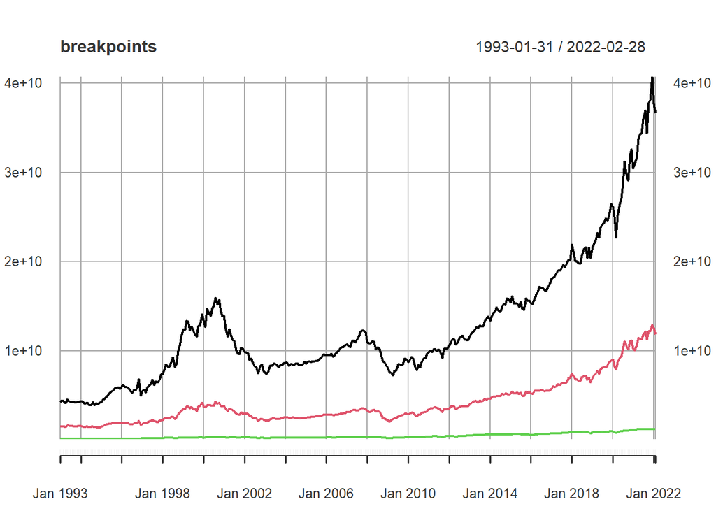

```r
MktCapPercentiles <- read.csv("MktCapPercentiles.csv")
breakpoints <- xts::xts(MktCapPercentiles[,-1], order.by=as.Date(MktCapPercentiles$Date))
plot(breakpoints)
```

These breakpoints can be used to assign the stocksCRSP and factorsSPGMI stocks to a cap grouping on a Point-in-Time basis with no look ahead bias:

```r
factorsSPGMI_tmp$MktCap <- exp(factorsSPGMI_tmp$LogMktCap)

factorsSPGMI_tmp$CapGroupLC <-
  MktCapPercentiles$LC[match(as.Date(factorsSPGMI_tmp$Date),as.Date(MktCapPercentiles$Date))]
factorsSPGMI_tmp$CapGroupMC <-
  MktCapPercentiles$MC[match(as.Date(factorsSPGMI_tmp$Date),as.Date(MktCapPercentiles$Date))]
factorsSPGMI_tmp$CapGroupSC <-
  MktCapPercentiles$SC[match(as.Date(factorsSPGMI_tmp$Date),as.Date(MktCapPercentiles$Date))]

factorsSPGMI_tmp$CapGroup <- ifelse(factorsSPGMI_tmp$MktCap < factorsSPGMI_tmp$CapGroupSC,"MicroCap",
                                    ifelse(factorsSPGMI_tmp$MktCap < factorsSPGMI_tmp$CapGroupMC,"SmallCap",
                                           ifelse(factorsSPGMI_tmp$MktCap < factorsSPGMI_tmp$CapGroupLC,"MidCap",
                                                  "LargeCap")))
```

Temporarily, we can create a “CapGroupLast” variable:

```r
end_dat <- factorsSPGMI_tmp[factorsSPGMI_tmp$Date == "2015-12-31",]
factorsSPGMI_tmp$CapGroupLast <- end_dat$CapGroup[match(factorsSPGMI_tmp$TickerLast,end_dat$TickerLast)]
```

Although as mentioned it is likely best not to use this and instead use the “most common” cap grouping for each stock.

```r
# match CapGroup and CapGroupL in stocksCRSP
factorsSPGMI_tmp$MatchVar <- paste(factorsSPGMI_tmp$Date,factorsSPGMI_tmp$Ticker,sep="-")
stocksCRSP_tmp$MatchVar <- paste(stocksCRSP_tmp$Date,stocksCRSP_tmp$Ticker,sep="-")
stocksCRSP_tmp$CapGroup <- factorsSPGMI_tmp$CapGroup[match(stocksCRSP_tmp$MatchVar,factorsSPGMI_tmp$MatchVar)]
stocksCRSP_tmp$CapGroupLast <- factorsSPGMI_tmp$CapGroupLast[match(stocksCRSP_tmp$MatchVar,factorsSPGMI_tmp$MatchVar)]
```

```r
# reorder columns
factorsSPGMI_tmp <- factorsSPGMI_tmp[,c("Date","Ticker","TickerLast","Company",
                                        "CapGroup","CapGroupLast","GICS",
                                        "Sector","AnnVol12M","Beta60M","BP","EP",
                                        "LogMktCap","PM12M1M","AccrualRatioCF",
                                        "AstAdjChg1YOCF","CFROIC","Chg1YAstTo",
                                        "EBITDAEV","FCFP","PM1M","SEV")]
head(factorsSPGMI_tmp)
```

```
##          Date Ticker TickerLast                   Company CapGroup CapGroupLast
## 1: 1993-01-31  ARONA        AAN                AARONS INC SmallCap     SmallCap
## 2: 1993-01-31    ABM        ABM      A B M INDUSTRIES INC SmallCap     SmallCap
## 3: 1993-01-31    ABT        ABT       ABBOTT LABORATORIES LargeCap     LargeCap
## 4: 1993-01-31   ADBE       ADBE                 ADOBE INC SmallCap     LargeCap
## 5: 1993-01-31    ADI        ADI        ANALOG DEVICES INC SmallCap     LargeCap
## 6: 1993-01-31    ADM        ADM ARCHER DANIELS MIDLAND CO LargeCap     LargeCap
##        GICS                 Sector AnnVol12M   Beta60M        BP         EP
## 1: 45301020 Information Technology 0.8710909 0.5682931 0.2387901 0.02408163
## 2: 20201050            Industrials 0.1526646 0.3729928 0.6526467 0.08141844
## 3: 35101010            Health Care 0.2803472 0.8700965 0.1448975 0.05090909
## 4: 45103010 Information Technology 0.5360764 1.5066980 0.2442777 0.05012048
## 5: 45301020 Information Technology 0.3671544 1.5433950 0.4645783 0.00606061
## 6: 30202010       Consumer Staples 0.2794455 1.1400930 0.5404809 0.05875761
##    LogMktCap     PM12M1M AccrualRatioCF AstAdjChg1YOCF     CFROIC  Chg1YAstTo
## 1:  19.14829 -0.37931030     0.01323480     0.13359010 0.50743580  0.03016533
## 2:  18.80814  0.04983389     0.02358503    -0.01704060 0.02627474  0.00110392
## 3:  23.87029 -0.03326810     0.15210980    -0.01832005 0.38003410  0.00833392
## 4:  20.65160 -0.48676170     0.65107710     0.07285196 0.40121460 -0.19936640
## 5:  20.48174  0.58024690     0.09836634    -0.06269938 0.06223698 -0.04897426
## 6:  22.86822 -0.05588235     0.20456710    -0.02882764 0.10656270 -0.08040183
##      EBITDAEV        FCFP        PM1M       SEV
## 1: 0.12676130 -0.10576160  0.36111110 0.5760557
## 2: 0.11883060 -0.03892129 -0.10759490 4.6771650
## 3: 0.09109676 -0.00631277 -0.10931170 0.3201372
## 4: 0.11727300  0.06800703  0.31746030 0.3244994
## 5: 0.08937147 -0.04238577  0.03125000 0.6621373
## 6: 0.11869030  0.01527499 -0.01869159 1.0612630
```

```r
stocksCRSP_tmp <- stocksCRSP_tmp[,c("Date","Ticker","TickerLast","Company",
                                    "CapGroup","CapGroupLast","GICS","Sector","Return",
                                    "RetExDiv","Price","PrcSplitAdj","Ret4WkBill",
                                    "Ret13WkBill","Ret1YrBill","mktIndexCRSP")]
head(stocksCRSP_tmp)
```

```
##          Date Ticker TickerLast                   Company CapGroup CapGroupLast
## 1: 1993-01-31  ARONA        AAN                AARONS INC SmallCap     SmallCap
## 2: 1993-01-31    ABM        ABM      A B M INDUSTRIES INC SmallCap     SmallCap
## 3: 1993-01-31    ABT        ABT       ABBOTT LABORATORIES LargeCap     LargeCap
## 4: 1993-01-31   ADBE       ADBE                 ADOBE INC SmallCap     LargeCap
## 5: 1993-01-31    ADI        ADI        ANALOG DEVICES INC SmallCap     LargeCap
## 6: 1993-01-31    ADM        ADM ARCHER DANIELS MIDLAND CO LargeCap     LargeCap
##        GICS                 Sector       Return     RetExDiv  Price PrcSplitAdj
## 1: 45301020 Information Technology  0.289473683  0.289473683 12.250    1.814815
## 2: 20201050            Industrials -0.112499997 -0.118749999 17.625    4.406250
## 3: 35101010            Health Care -0.089711934 -0.094650209 27.500    6.166759
## 4: 45103010 Information Technology  0.319999993  0.317460328 41.500    2.560229
## 5: 45301020 Information Technology  0.015384615  0.015384615 16.500    2.750007
## 6: 30202010       Consumer Staples -0.009433962 -0.009433962 26.250   11.280660
##     Ret4WkBill Ret13WkBill  Ret1YrBill mktIndexCRSP
## 1: 0.001459064 0.001583069 0.001836982   0.01264374
## 2: 0.001459064 0.001583069 0.001836982   0.01264374
## 3: 0.001459064 0.001583069 0.001836982   0.01264374
## 4: 0.001459064 0.001583069 0.001836982   0.01264374
## 5: 0.001459064 0.001583069 0.001836982   0.01264374
## 6: 0.001459064 0.001583069 0.001836982   0.01264374
```

Final checks:

```r
# confirm factorsSPGMI and stocksCRSP have correct sectors
unique(factorsSPGMI_tmp$Sector) #8 sectors with no duplicates
```

```
## [1] "Information Technology" "Industrials"            "Health Care"
## [4] "Consumer Staples"       "Energy"                 "Materials"
## [7] "Consumer Discretionary" "Communication Services"
```

```r
unique(stocksCRSP_tmp$Sector) #8 sectors with no duplicates
```

```
## [1] "Information Technology" "Industrials"            "Health Care"
## [4] "Consumer Staples"       "Energy"                 "Materials"
## [7] "Consumer Discretionary" "Communication Services"
```

```r
stocksCRSPLast <- stocksCRSP_tmp[Date == lastDateCRSP]
stocksCRSPLast[ , .N, by = Sector]
```

```
##                    Sector  N
## 1: Information Technology 41
## 2:            Industrials 92
## 3:            Health Care 31
## 4:       Consumer Staples 29
## 5:                 Energy 20
## 6:              Materials 26
## 7: Consumer Discretionary 46
## 8: Communication Services  9
```

```r
factorsSPGMILast <- factorsSPGMI_tmp[Date == lastDateCRSP]
factorsSPGMILast[ , .N, by = Sector]
```

```
##                    Sector  N
## 1: Information Technology 41
## 2:            Industrials 92
## 3:            Health Care 31
## 4:       Consumer Staples 29
## 5:                 Energy 20
## 6:              Materials 26
## 7: Consumer Discretionary 46
## 8: Communication Services  9
```

```r
dim(stocksCRSP_tmp)
```

```
## [1] 81144    16
```

```r
dim(factorsSPGMI_tmp)
```

```
## [1] 81144    22
```

factorsSPGMI_tmp and stocksCRSP_tmp now have 294 securities with 276 months of data, properly assigned to the 8 remaining sectors with official GICS naming conventions, with cap groups assigned roughly in accordance to the official CRSP methodology using the broad market (that is, >3000 stocks per month) to set the breakpoints.